# OBIS | Caracterización espacio-temporal y taxonómica de registros de biodiversidad marina

Proyecto 1 · OceanHackWeek en Español 2026

## 1. ¿Qué hace este QMD?

Este QMD descarga registros de ocurrencia de **OBIS** para un dominio geográfico y periodo definidos, los integra en una base única y aplica procesos de **depuración, validación y estandarización taxonómica, espacial y temporal**. Luego realiza un **análisis exploratorio de datos (EDA)** para describir la distribución de los registros por año, mes y grupo taxonómico, así como su cobertura y continuidad espacio-temporal. El objetivo es identificar conjuntos biológicos con información adecuada para análisis posteriores de **diversidad** y su relación con **variables oceanográficas**, manteniendo la trazabilidad de los datos y la representatividad del muestreo.

Como referencia espacial para el archipiélago de Galápagos. Esta figura muestra las cuatro bioregiones principales del archipiélago (**far-north, north, centre-south y cold-west**), los estratos geográficos definidos a lo largo de la costa y la ubicación general de Galápagos en el Pacífico Oriental Tropical.

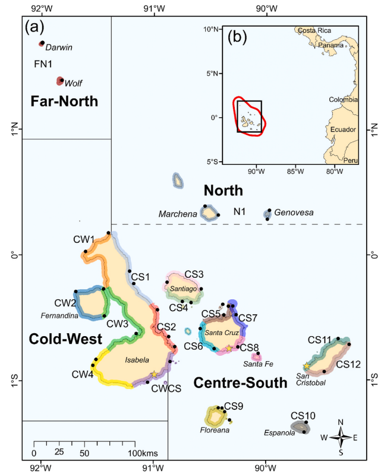

**Figura 1.** Mapa del archipiélago de Galápagos adaptado de McKinley et al. (2023)

## 2. Configuración y funciones

**Mostrar código R**

```r
required <- c(
  "robis",
  "dplyr",
  "readr",
  "ggplot2",
  "tibble",
  "cowplot"
)

missing <- required[
  !vapply(required, requireNamespace, logical(1), quietly = TRUE)
]

if (length(missing) > 0L) {
  stop(
    "Instala los paquetes faltantes: install.packages(c(",
    paste(shQuote(missing), collapse = ", "),
    "))"
  )
}

root <- if (file.exists("main.R")) {
  "."
} else if (file.exists(file.path("R", "main.R"))) {
  "."
} else {
  stop("No se encontró main.R en el directorio actual")
}

root <- normalizePath(root, winslash = "/")

main_file <- if (file.exists(file.path(root, "main.R"))) {
  file.path(root, "main.R")
} else {
  file.path(root, "R", "main.R")
}

source(main_file, local = TRUE)

required_functions <- c(
  "obis_cell_accumulation_screening",
  "obis_clean_standardize",
  "obis_download_period",
  "obis_eda_tables",
  "obis_event_coverage_by_year",
  "obis_integrate_raw",
  "obis_paths",
  "obis_plot_cell_accumulation",
  "obis_plot_map_taxa",
  "obis_plot_map_years",
  "obis_plot_record_thinning",
  "obis_plot_saturation_domain",
  "obis_plot_saturation_map",
  "obis_plot_saturation_thresholds",
  "obis_plot_spatial_facets",
  "obis_rarefaction_screening",
  "obis_record_thinning_screening",
  "obis_records_saturation_screening",
  "obis_selected_years",
  "obis_spatial_screening",
  "obis_taxon_suitability",
  "obis_taxonomic_screening",
  "obis_validate_config",
  "obis_wkt",
  "obis_write_csv"
)

obis_assert_functions(
  required_functions,
  env = environment()
)

#configuración
ggplot2::theme_set(
  cowplot::theme_cowplot(font_size = 11)
)

p <- params

obis_validate_config(p)

years <- seq.int(
  as.integer(p$year_start),
  as.integer(p$year_end)
)

paths <- obis_paths(root)
wkt <- obis_wkt(p)
lon_range <- p$lon_max - p$lon_min
lat_range <- p$lat_max - p$lat_min

grid_res <- if (!is.null(p$grid_res)) {
  as.numeric(p$grid_res)
} else {
  NA_real_
}

has_grid <- length(grid_res) == 1L &&
  is.finite(grid_res) &&
  grid_res > 0

if (has_grid) {
  n_lon <- ceiling(lon_range / grid_res)
  n_lat <- ceiling(lat_range / grid_res)
  n_cells <- n_lon * n_lat
} else {
  n_lon <- NA_integer_
  n_lat <- NA_integer_
  n_cells <- NA_integer_
}

line <- paste(rep("=", 72), collapse = "")
separator <- paste(rep("-", 72), collapse = "")

cat(
  "\n", line, "\n",
  " OBIS | CONFIGURACIÓN DEL PROYECTO\n",
  line, "\n\n",

  " 01. PROYECTO\n",
  separator, "\n",
  " Directorio raíz      : ", root, "\n",
  " Archivo de funciones : ", main_file, "\n",
  " Funciones verificadas: ", length(required_functions), "\n",
  " Tema gráfico         : cowplot::theme_cowplot()\n\n",

  " 02. DOMINIO GEOGRÁFICO\n",
  separator, "\n",
  " Longitud             : ", p$lon_min, " a ", p$lon_max, "°\n",
  " Latitud              : ", p$lat_min, " a ", p$lat_max, "°\n",
  " Extensión longitudinal: ", lon_range, "°\n",
  " Extensión latitudinal : ", lat_range, "°\n",
  " Geometría de consulta: POLYGON (WKT)\n\n",

  " 03. RESOLUCIÓN ESPACIAL\n",
  separator, "\n",
  " Resolución de grilla : ",
  if (has_grid) paste0(grid_res, "° x ", grid_res, "°") else "No definida",
  "\n",
  " Columnas             : ", if (has_grid) n_lon else "NA", "\n",
  " Filas                : ", if (has_grid) n_lat else "NA", "\n",
  " Celdas geométricas   : ",
  if (has_grid) format(n_cells, big.mark = ",", scientific = FALSE) else "NA",
  "\n\n",

  " 04. COBERTURA TEMPORAL\n",
  separator, "\n",
  " Año inicial          : ", min(years), "\n",
  " Año final            : ", max(years), "\n",
  " Años evaluados       : ", length(years), "\n\n",

  " 05. DESCARGA Y ANÁLISIS\n",
  separator, "\n",
  " Descarga OBIS        : ",
  if (isTRUE(p$execute_download)) "ACTIVADA" else "DESACTIVADA",
  "\n",
  " Rarefacción eventos  : ",
  if (isTRUE(p$run_rarefaction)) "ACTIVADA" else "DESACTIVADA",
  "\n",
  " Saturación eventos : ",
  if (!is.null(p$n_saturation_groups_per_rank)) "CONFIGURADA" else "No configurada"
)
```

```
 ========================================================================
  OBIS | CONFIGURACIÓN DEL PROYECTO
 ========================================================================

  01. PROYECTO
 ------------------------------------------------------------------------
  Directorio raíz      :  D:/ios/OceanHackWeek2026/ohwe26-proy1-GBIF_analisis_espacial/projectOBIS
  Archivo de funciones :  D:/ios/OceanHackWeek2026/ohwe26-proy1-GBIF_analisis_espacial/projectOBIS/main.R
  Funciones verificadas:  25
  Tema gráfico         : cowplot::theme_cowplot()

  02. DOMINIO GEOGRÁFICO
 ------------------------------------------------------------------------
  Longitud             :  -93  a  -88.5 °
  Latitud              :  -2  a  2.2 °
  Extensión longitudinal:  4.5 °
  Extensión latitudinal :  4.2 °
  Geometría de consulta: POLYGON (WKT)

  03. RESOLUCIÓN ESPACIAL
 ------------------------------------------------------------------------
  Resolución de grilla :  0.25° x 0.25°
  Columnas             :  18
  Filas                :  17
  Celdas geométricas   :  306

  04. COBERTURA TEMPORAL
 ------------------------------------------------------------------------
  Año inicial          :  1994
  Año final            :  2025
  Años evaluados       :  32

  05. DESCARGA Y ANÁLISIS
 ------------------------------------------------------------------------
  Descarga OBIS        :  ACTIVADA
  Rarefacción eventos  :  DESACTIVADA
  Saturación eventos :  No configurada
```

## 3. Descarga e integración anual de ocurrencias

Se realiza **una consulta por año**, conservando todos los campos en OBIS en CSV, y se integran los archivos anuales mediante `dplyr::bind_rows()`.

**Mostrar código R**

```r
manifest <- obis_download_period(years,wkt,paths$raw,p$execute_download)
obis_write_csv(manifest,file.path(paths$tab,"00_write_descargas.csv"))
print(manifest)
```

```
# A tibble: 32 × 4
    year status    records detail
   <int> <chr>       <int> <chr>
 1  1994 EXISTENTE     934 ""
 2  1995 EXISTENTE    1309 ""
 3  1996 EXISTENTE     720 ""
 4  1997 EXISTENTE    1887 ""
 5  1998 EXISTENTE    6007 ""
 6  1999 EXISTENTE    6630 ""
 7  2000 EXISTENTE   11175 ""
 8  2001 EXISTENTE   12294 ""
 9  2002 EXISTENTE   12544 ""
10  2003 EXISTENTE    6679 ""
# ℹ 22 more rows
```

**Mostrar código R**

```r
raw_all <- obis_integrate_raw(manifest,years,paths$raw)

if (is.null(raw_all)) {
  warning("Faltan años o existen CSV inválidos: consulta cout/obis/tab/manifest_descargas.csv")
} else {
  cat("Ocurrencias:",nrow(raw_all),"\nColumnas:",ncol(raw_all),"\n")
}
```

```
Ocurrencias: 203632
Columnas: 211
```

## 4. Depuración y estandarización

Se conservan registros georreferenciados, identificados a nivel de especie y de afinidad marina confirmada. Se excluyen fósiles, ausencias, duplicados, registros descartados por OBIS y alertas explícitas de tierra. Se revisa cada exclusión.

**Mostrar código R**

```r
processed <- obis_clean_standardize(raw_all,p)

clean <- if(is.null(processed)) NULL else processed$clean

if (!is.null(processed)) {
  obis_write_csv(processed$audit,file.path(paths$tab,"01_rev_depuracion.csv"))
  obis_write_csv(dplyr::count(processed$quality,source_year,reason,name="n"),
                 file.path(paths$tab,"01_rev_por_anio.csv"))
  obis_write_csv(processed$missing_fields,file.path(paths$tab,"01_rev_campos.csv"))
  print(processed$audit)
  cat("Registros retenidos:",nrow(clean),"\n")
}
```

```
# A tibble: 5 × 3
  reason                             n percent
  <chr>                          <int>   <dbl>
1 AFINIDAD_MARINA_NO_CONFIRMADA    151    0.07
2 ALERTA_TIERRA                  38778   19.0
3 NO_IDENTIFICADO_A_ESPECIE      21962   10.8
4 RETIENE                       142741   70.1
5 DUPLICADO_ID_OBIS                  0    0
Registros retenidos: 142741
```

## 5. Evaluación de grupos taxonómicos

La selección exploratoria considera el número de especies, años representados, continuidad temporal y diversidad de conjuntos de datos, por **filo, clase, orden**.

**Mostrar código R**

```r
screening <- obis_taxonomic_screening(clean,years)

if(!is.null(screening)) {
  obis_write_csv(screening$representativity,
                 file.path(paths$tab,"02_candidatos_taxonomicos.csv"))
  obis_write_csv(screening$yearly_taxa,
                 file.path(paths$tab,"02_registros_por_anio_y_taxon.csv"))

  print(utils::head(dplyr::arrange(screening$representativity,
                                   dplyr::desc(species),
             dplyr::desc(years_present),dplyr::desc(records)),25),n = 10)
}
```

```
# A tibble: 25 × 15
   group           rank   records species years_present first_year last_year
   <chr>           <chr>    <int>   <int>         <int>      <int>     <int>
 1 Chordata        phylum   82085     549            32       1994      2025
 2 Teleostei       class    64433     403            32       1994      2025
 3 Mollusca        phylum    3642     209            32       1994      2025
 4 Gastropoda      class     2948     160            32       1994      2025
 5 Arthropoda      phylum   18886     159            32       1994      2025
 6 Malacostraca    class    18265     144            32       1994      2025
 7 Decapoda        order    18257     139            32       1994      2025
 8 Cnidaria        phylum    5937     120            31       1994      2025
 9 Echinodermata   phylum   22184     111            32       1994      2025
10 Florideophyceae class     1338      95            29       1994      2025
# ℹ 15 more rows
# ℹ 8 more variables: longest_consecutive_run <int>, months_present <int>,
#   datasets <int>, dominant_dataset_share <dbl>, distinct_locations <int>,
#   five_year_blocks <int>, fraction_years <dbl>, coverage_screen <lgl>
```

## 6. EDA de registros

La Figura 1 presenta el número de ocurrencias documentadas por año, considerando todos los grupos taxonómicos retenidos después de la depuración.

**Mostrar código R**

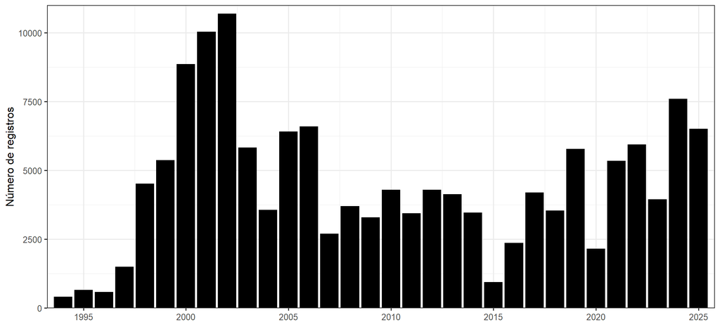

Figura 1: Distribución anual de registros de ocurrencia de biodiversidad marina en el archipiélago de Galápagos durante 1994–2025. Fuente: OBIS, datos depurados.

```r
eda <- obis_eda_tables(clean)
obis_write_csv(eda$year_month,
                 file.path(paths$tab,"03_registros_por_anio_mes.csv"))

g1 <- ggplot2::ggplot(eda$yearly,ggplot2::aes(year_analysis,records)) +
    ggplot2::geom_col(fill = "#000000") +
    ggplot2::labs(
      title = NULL,x = NULL,y = "Número de registros") +
    ggplot2::scale_x_continuous(breaks = seq(1995, 2025, by = 5), expand = c(0.01, 0.01)) +
    ggplot2::scale_y_continuous(expand = c(0, 0), limits = c(0, 11*1E3)) +
    ggplot2::theme_bw(base_size = 12)

  print(g1)
  ggplot2::ggsave(file.path(paths$fig,"03_registros_por_anio.png"),g1,
                  width = 11*0.7, height = 5*0.7, dpi = 350, bg = "white")
```

La Figura 2 muestra la distribución de los registros de ocurrencia por año y mes, permitiendo identificar periodos de mayor documentación y posibles discontinuidades temporales en la información disponible.

**Mostrar código R**

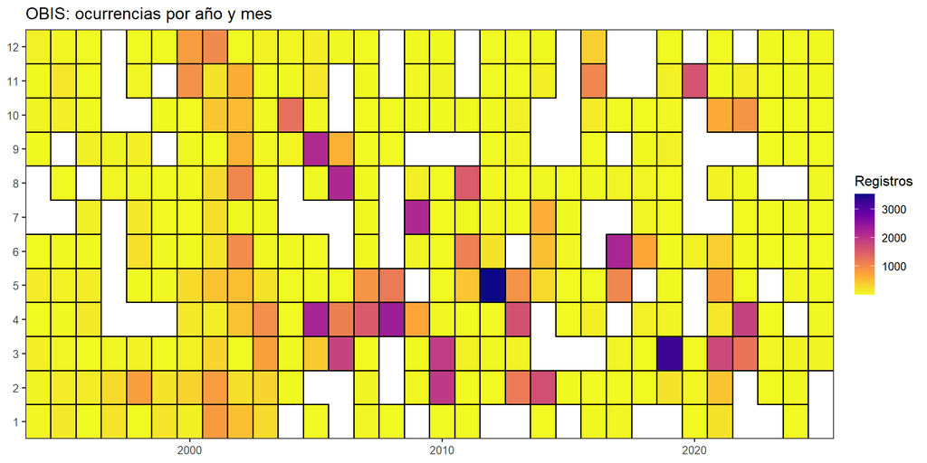

Figura 2: Distribución de registros de ocurrencia de biodiversidad marina por año y mes en el archipiélago de Galápagos durante 1994–2025. Los espacios sin color indican combinaciones año-mes sin registros documentados. Fuente: OBIS, datos depurados.

```r
  g3 <- ggplot2::ggplot(eda$year_month,
                        ggplot2::aes(year_analysis,month_analysis,fill=records)) +
    ggplot2::geom_tile(colour = "#000000", linewidth = 0.7) +
    ggplot2::scale_fill_viridis_c(option = "plasma", direction = -1) +
    ggplot2::labs(title = "OBIS: ocurrencias por año y mes", x = NULL, y = NULL, fill = "Registros") +
    ggplot2::scale_x_continuous(expand = c(0, 0)) +
    ggplot2::scale_y_continuous(breaks = 1:12, expand = c(0, 0)) +
    ggplot2::theme_bw(base_size = 12) +
    ggplot2::theme(panel.grid = ggplot2::element_blank())


  print(g3)

  ggplot2::ggsave(file.path(paths$fig,"03_anio_mes.png"), g3,
                 width = 11*0.8, height = 5*0.7, dpi = 350, bg = "white")
```

**Mostrar código R**

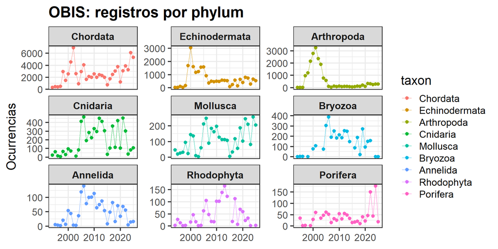

Figura 3: Variación anual de los registros de ocurrencia de los nueve grupos más documentados en OBIS para Galápagos durante 1994–2025. Las escalas verticales son independientes entre paneles. Fuente: OBIS, datos depurados.

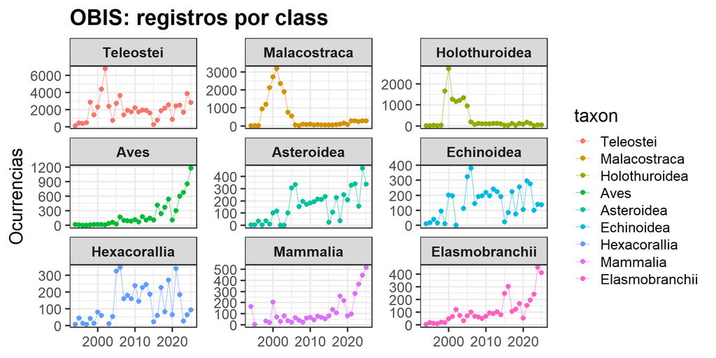

Figura 4: Variación anual de los registros de ocurrencia de los nueve grupos más documentados en OBIS para Galápagos durante 1994–2025. Las escalas verticales son independientes entre paneles. Fuente: OBIS, datos depurados.

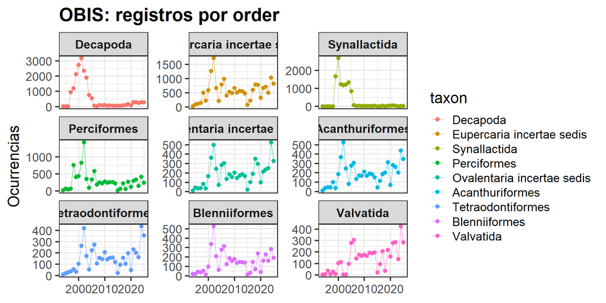

Figura 5: Variación anual de los registros de ocurrencia de los nueve grupos más documentados en OBIS para Galápagos durante 1994–2025. Las escalas verticales son independientes entre paneles. Fuente: OBIS, datos depurados.

```r
  if (!is.null(screening)) {

  for (nivel in c("phylum", "class", "order")) {

    tax <- screening$yearly_taxa |>
      dplyr::filter(.data$rank == .env$nivel)

    leaders <- tax |>
      dplyr::group_by(taxon) |>
      dplyr::summarise(
        total = sum(records, na.rm = TRUE),
        .groups = "drop"
      ) |>
      dplyr::arrange(dplyr::desc(total)) |>
      dplyr::slice_head(n = 9)

   plot_data <- tax |>
  dplyr::filter(.data$taxon %in% leaders$taxon) |>
  tidyr::complete(
    taxon = leaders$taxon,
    year_analysis = seq.int(p$year_start, p$year_end),
    fill = list(records = NA_integer_)
  ) |>
  dplyr::mutate(
    taxon = factor(.data$taxon, levels = leaders$taxon)
  ) |>
  dplyr::arrange(.data$taxon, .data$year_analysis)

    if (nrow(plot_data) == 0) next

    plot <- ggplot2::ggplot(
      plot_data,
      ggplot2::aes(
        x = year_analysis,
        y = records,
        color = taxon,
        group = taxon
      )
    ) +
      ggplot2::geom_line(linewidth = 0.3) +
      ggplot2::geom_point(size = 1.5) +
      ggplot2::facet_wrap(~ taxon, scales = "free_y", ncol = 3) +
      ggplot2::labs(
        title = paste("OBIS: registros por", nivel),
        x = NULL,
        y = "Ocurrencias"
      ) +
      ggplot2::theme_bw(base_size = 18) +
      ggplot2::theme(
        strip.text = ggplot2::element_text(face = "bold"),
        plot.title = ggplot2::element_text(face = "bold")
      )

    print(plot)

    ggplot2::ggsave(
      filename = file.path(paths$fig, paste0("04_taxones_", nivel, "_facet.png")),
      plot = plot,
      width = 8,
      height = 5,
      dpi = 350,
      bg = "white"
    )
  }
}
```

## 7. Representatividad espacial por grupo taxonómico

Se evalúa **qué tan distribuidos espacialmente están los registros** antes de seleccionar un grupo para estudiar diversidad con la cuadrícula de `grid_res` grados. Se resumen registros, celdas con observaciones y concentración espacial **por año y por filo, clase u orden**. Las celdas sin registros no se interpretan como ausencias.

**Mostrar código R**

```r
spatial <- NULL
if (!is.null(clean) && nrow(clean)) {

  spatial <- obis_spatial_screening(
    clean = clean,
    p = p,
    grid_res = p$grid_res,
    ranks = c("phylum", "class", "order")
  )

  obis_write_csv(spatial$cell_counts,
                 file.path(paths$tab, "05_celdas_por_taxon_anio.csv"))
  obis_write_csv(spatial$annual,
                 file.path(paths$tab, "05_cobertura_espacial_taxon_anio.csv"))
  obis_write_csv(spatial$summary,
                 file.path(paths$tab, "05_cobertura_espacial_taxon_resumen.csv"))

  print(utils::head(spatial$summary, 20), n = 20)
}
```

```
# A tibble: 20 × 12
   rank  taxon           years_observed_spatial total_records median_cells_year
   <chr> <chr>                            <int>         <int>             <dbl>
 1 class Teleostei                           32         64433              28.5
 2 class Malacostraca                        32         18265              25
 3 class Holothuroidea                       32         12234              15.5
 4 class Aves                                32          6664              21
 5 class Asteroidea                          32          5098              14
 6 class Echinoidea                          31          4732              17
 7 class Hexacorallia                        31          3980              14
 8 class Mammalia                            30          3759              23.5
 9 class Elasmobranchii                      32          3655              17.5
10 class Gymnolaemata                        26          3116              13
11 class Gastropoda                          32          2948              15.5
12 class Hydrozoa                            28          1689               9.5
13 class Polychaeta                          31          1526              12
14 class Ascidiacea                          24          1364              11
15 class Florideophyceae                     29          1338               6
16 class Demospongiae                        29          1104              10
17 class Thecostraca                         29           618               8
18 class Stenolaemata                        19           481              11
19 class Phaeophyceae                        25           432               4
20 class Bivalvia                            30           358               5
# ℹ 7 more variables: mean_cells_year <dbl>, median_max_cell_share <dbl>,
#   mean_max_cell_share <dbl>, median_event_annotated_fraction <dbl>,
#   median_effective_cells <dbl>, years_ge_5_cells <int>,
#   years_ge_10_cells <int>
```

### Distribución espacial anual por grupo

Las facetas conservan el orden de **mayor a menor número total de registros**. La primera figura muestra cuántas celdas cuentan con registros; la segunda, la proporción de registros concentrados en la celda dominante; la tercera, el promedio de registros por celda ocupada.

**Mostrar código R**

```r
if (!is.null(spatial) && nrow(spatial$annual)) {
  for (nivel in c("class")) {
    for (metric in c("n_cells", "max_cell_share", "mean_records_per_cell")) {
      plot <- obis_plot_spatial_facets(
        annual = spatial$annual,
        rank_value = nivel,
        metric = metric,
        n_top = 9
      )
      if (is.null(plot)) next
      print(plot)

      ggplot2::ggsave(
        filename = file.path(paths$fig, paste0("05_espacial_", nivel, "_", metric, ".png")),
        width = 8,
      height = 5,
      dpi = 350,
      bg = "white"
    )
    }
  }
}
```

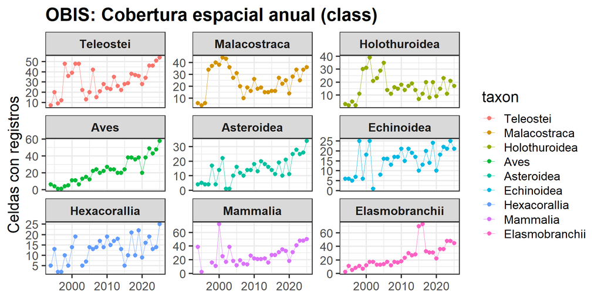

(a) Número de celdas geográficas con registros por año.

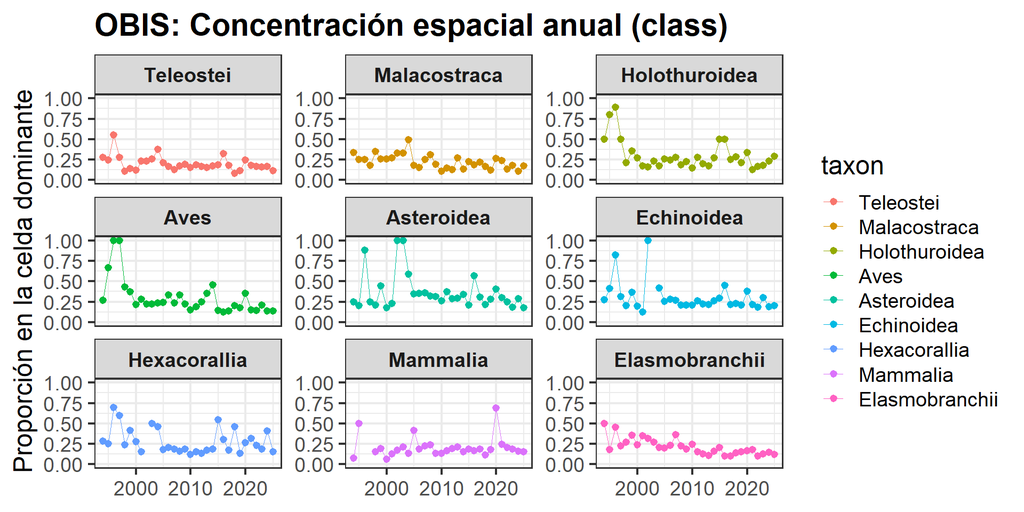

(b) Proporción de registros concentrados en la celda dominante por año.

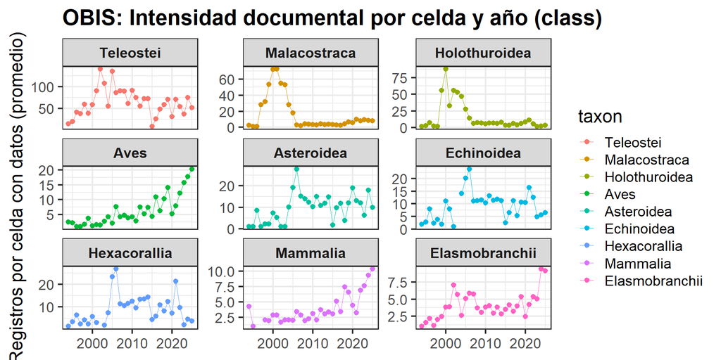

(c) Número promedio de registros por celda documentada y año.

Figura 6: Variación espacio-temporal de la cobertura, concentración e intensidad documental de las nueve clases taxonómicas con mayor número de registros en Galápagos durante 1994–2025.

[output not shown]

## 8. Diagnóstico para seleccionar grupos

Se combinan indicadores temporales y espaciales para **comparar clases**. La evaluación incluye número de especies identificadas, años con registros, racha de continuidad, celdas observadas por año, dominancia de la celda principal y procedencia de los registros.

**Mostrar código R**

```r
suitability <- NULL
if (!is.null(spatial) && !is.null(screening)) {
  suitability <- obis_taxon_suitability(
    representativity = screening$representativity,
    spatial_summary = spatial$summary
  )
  obis_write_csv(suitability,
                 file.path(paths$tab, "06_idoneidad_taxonomica_espaciotemporal.csv"))
  print(utils::head(suitability, 30), n = 10)
}
```

```
# A tibble: 30 × 28
   group          rank  records species years_present first_year last_year
   <chr>          <chr>   <int>   <int>         <int>      <int>     <int>
 1 Teleostei      class   64433     403            32       1994      2025
 2 Malacostraca   class   18265     144            32       1994      2025
 3 Holothuroidea  class   12234      26            32       1994      2025
 4 Aves           class    6664      49            32       1994      2025
 5 Asteroidea     class    5098      34            32       1994      2025
 6 Echinoidea     class    4732      25            31       1994      2025
 7 Hexacorallia   class    3980      69            31       1994      2025
 8 Mammalia       class    3759      26            30       1994      2025
 9 Elasmobranchii class    3655      34            32       1994      2025
10 Gymnolaemata   class    3116      16            26       1994      2025
# ℹ 20 more rows
# ℹ 21 more variables: longest_consecutive_run <int>, months_present <int>,
#   datasets <int>, dominant_dataset_share <dbl>, distinct_locations <int>,
#   five_year_blocks <int>, fraction_years <dbl>, coverage_screen <lgl>,
#   years_observed_spatial <int>, total_records <int>, median_cells_year <dbl>,
#   mean_cells_year <dbl>, median_max_cell_share <dbl>,
#   mean_max_cell_share <dbl>, median_event_annotated_fraction <dbl>, …
```

**Mostrar código R**

```r
if (is.null(clean) || nrow(clean) == 0L) {
  stop("No existen registros depurados para seleccionar Teleostei.")
}

teleostei <- clean |>
  dplyr::filter(
    !is.na(.data$class),
    trimws(.data$class) == "Teleostei",
    !is.na(.data$species_accepted),
    trimws(.data$species_accepted) != ""
  ) |>
  dplyr::arrange(
    .data$year_analysis,
    .data$month_analysis,
    .data$species_accepted
  )

stopifnot(
  nrow(teleostei) > 0L,
  all(teleostei$class == "Teleostei"),
  all(teleostei$year_analysis %in% years)
)

file_teleostei <- file.path(
  paths$cin,
  sprintf(
    "obis_teleostei_%d_%d.csv",
    min(years),
    max(years)
  )
)

obis_write_csv(
  teleostei,
  file_teleostei
)

summary_teleostei <- tibble::tibble(
  taxon = "Teleostei",
  records = nrow(teleostei),
  species = dplyr::n_distinct(teleostei$species_accepted),
  years = dplyr::n_distinct(teleostei$year_analysis),
  first_year = min(teleostei$year_analysis),
  last_year = max(teleostei$year_analysis),
  columns = ncol(teleostei)
)

print(summary_teleostei)
```

```
# A tibble: 1 × 7
  taxon     records species years first_year last_year columns
  <chr>       <int>   <int> <int>      <int>     <int>   <int>
1 Teleostei   64433     403    32       1994      2025      45
```

**Mostrar código R**

```r
teleostei_annual <- teleostei |>
  dplyr::group_by(.data$year_analysis) |>
  dplyr::summarise(
    records = dplyr::n(),
    species = dplyr::n_distinct(.data$species_accepted),
    .groups = "drop"
  ) |>
  tidyr::complete(
    year_analysis = years,
    fill = list(
      records = NA_integer_,
      species = NA_integer_
    )
  ) |>
  dplyr::arrange(.data$year_analysis)

obis_write_csv(
  teleostei_annual,
  file.path(paths$tab, "09_teleostei_resumen_anual.csv")
)

print(teleostei_annual)
```

```
# A tibble: 32 × 3
   year_analysis records species
           <int>   <int>   <int>
 1          1994     104      52
 2          1995     402     150
 3          1996     374      73
 4          1997     453     106
 5          1998    2854     172
 6          1999    1399     119
 7          2000    2291     129
 8          2001    4375     152
 9          2002    6755     168
10          2003    2375     135
# ℹ 22 more rows
```

## 9. Caracterización taxonómica de Teleostei

Se evalúa la composición taxonómica de Teleostei mediante el número de ocurrencias, riqueza registrada y continuidad temporal de sus principales órdenes, familias, géneros y especies. Esta caracterización permite identificar los grupos predominantes y orientar la selección de ensamblajes ecológicamente coherentes.

**Mostrar código R**

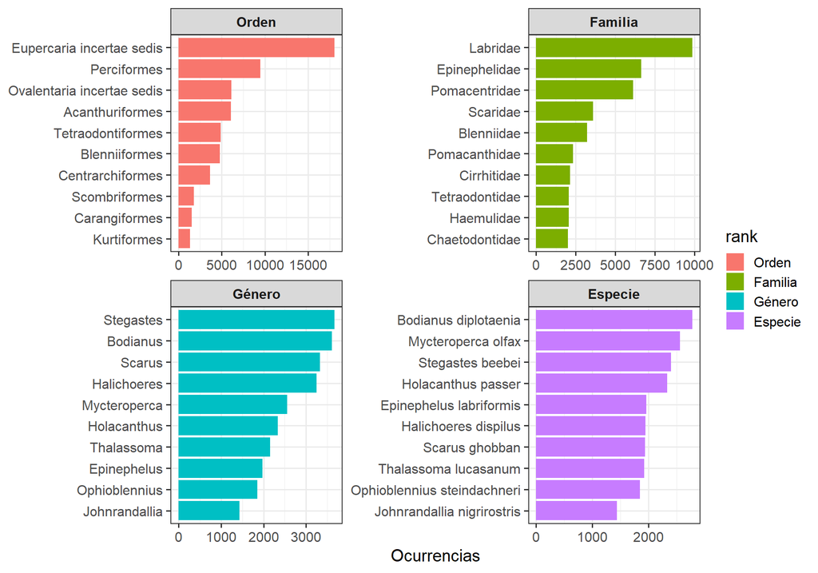

Figura 7: Principales órdenes, familias, géneros y especies de Teleostei según el número acumulado de ocurrencias en Galápagos durante 1994–2025.

```r
tax_rank <- teleostei |>
  tidyr::pivot_longer(
    cols = c(order, family, genus, species_accepted),
    names_to = "rank",
    values_to = "taxon"
  ) |>
  dplyr::filter(!is.na(taxon), taxon != "") |>
  dplyr::count(rank, taxon, name = "records") |>
  dplyr::arrange(rank, dplyr::desc(records))

obis_write_csv(
  tax_rank,
  file.path(paths$tab, "10_teleostei_rankings.csv")
)

top_taxa <- tax_rank |>
  dplyr::group_by(rank) |>
  dplyr::slice_max(
    records, n = 10, with_ties = FALSE
  ) |>
  dplyr::ungroup() |>
  dplyr::mutate(
    rank = factor(
      rank,
      levels = c("order", "family", "genus", "species_accepted"),
      labels = c("Orden", "Familia", "Género", "Especie")
    ),
    taxon_key = paste(rank, taxon, sep = "___")
  ) |>
  dplyr::arrange(records) |>
  dplyr::mutate(
    taxon_key = factor(taxon_key, levels = unique(taxon_key))
  )

g_rank <- ggplot2::ggplot(
  top_taxa,
  ggplot2::aes(taxon_key, records, fill = rank)
) +
  ggplot2::geom_col() +
  ggplot2::facet_wrap(~ rank, scales = "free", ncol = 2) +
  ggplot2::coord_flip() +
  ggplot2::scale_x_discrete(
    labels = function(x) sub("^.*___", "", x)
  ) +
  ggplot2::labs(x = NULL, y = "Ocurrencias") +
  ggplot2::theme_bw(base_size = 15) +
  ggplot2::theme(
    strip.text = ggplot2::element_text(face = "bold")
  )

print(g_rank)

ggplot2::ggsave(
  file.path(paths$fig, "10_teleostei_rankings.png"),
  g_rank, width = 12, height = 9,
  dpi = 350, bg = "white"
)
```

## 10. Caracterización y representatividad de los grupos ecológicos de Teleostei

La diversidad de Teleostei comprende especies con diferentes afinidades de hábitat, estrategias ecológicas y patrones de distribución espacial. Por ello, se realiza una clasificación ecológica a nivel de especie para identificar ensamblajes potencialmente adecuados para estudios de diversidad y variabilidad ambiental en el archipiélago de Galápagos.

Se evalúa la representatividad de cada grupo mediante el número de ocurrencias, riqueza observada, cobertura y continuidad temporal. Este diagnóstico, complementado con los antecedentes de investigación sobre comunidades de peces arrecifales en Galápagos (Edgar et al., 2004; Bruneel et al., 2021; McKinley et al., 2022, 2023), permite sustentar la selección preliminar del ensamblaje focal.

### 10.1. Clasificación ecológica por especie

La clasificación ecológica preliminar considera la afinidad de hábitat de cada especie, tomando como fuentes de referencia FishBase, Shorefishes of the Eastern Pacific, la lista regional de peces de Galápagos (Victor et al., 2026) y los inventarios de los estudios sobre comunidades arrecifales (Edgar et al., 2004; McKinley et al., 2022, 2023).

Se establecen siete categorías ecológicas, ilustradas mediante especies representativas de cada grupo.

Imagen representativa

Grupo ecológico

Especie representativa

Descripción

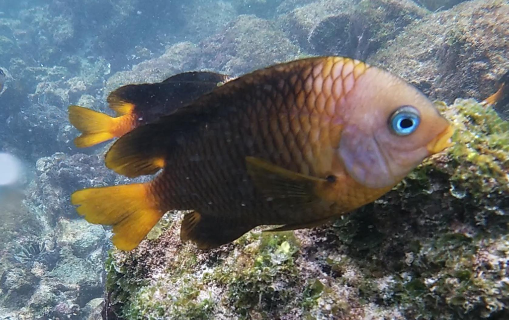

**Arrecifal**

*Stegastes arcifrons*

Especies estrechamente asociadas a arrecifes y fondos rocosos.

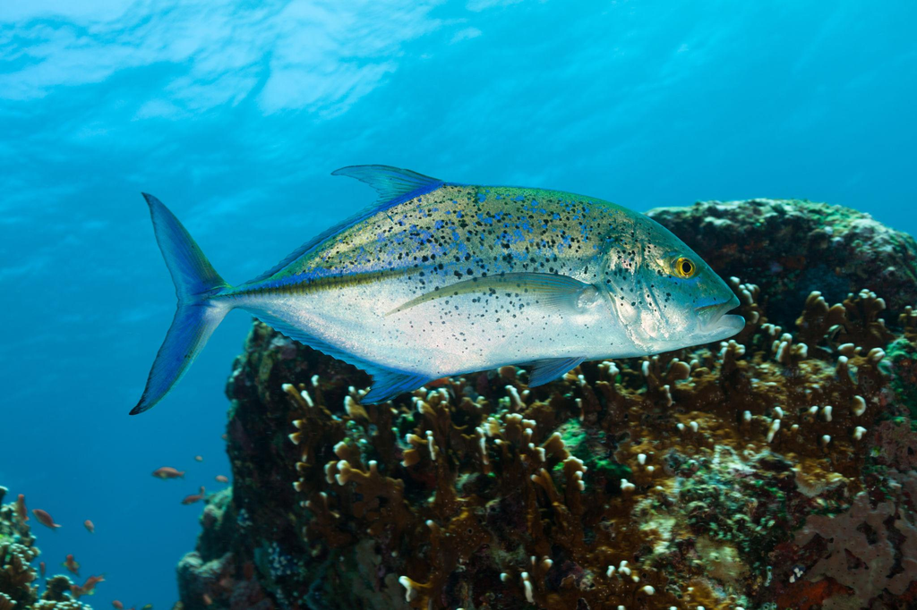

**Asociación arrecifal variable**

*Caranx melampygus*

Especies que utilizan ambientes arrecifales, pero también otros hábitats.

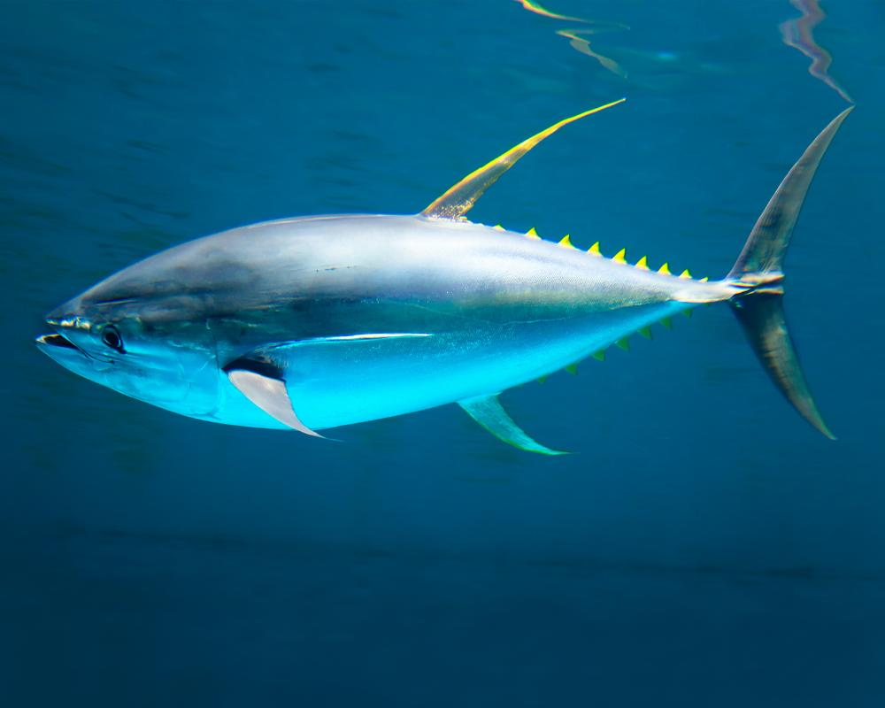

**Pelágico**

*Thunnus albacares*

Especies asociadas principalmente a la columna de agua.

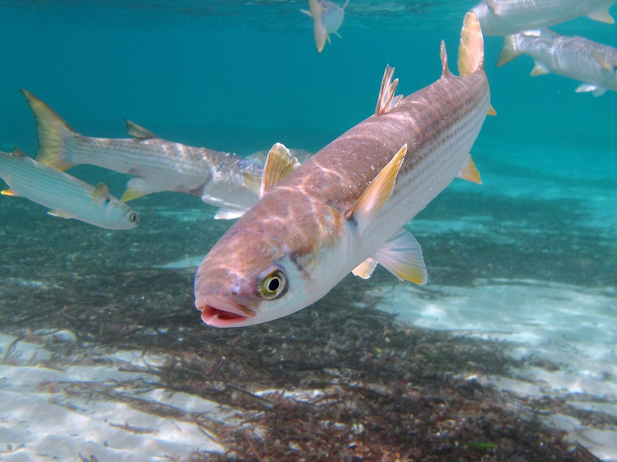

**Costero generalista**

*Mugil cephalus*

Especies que utilizan diversos hábitats costeros.

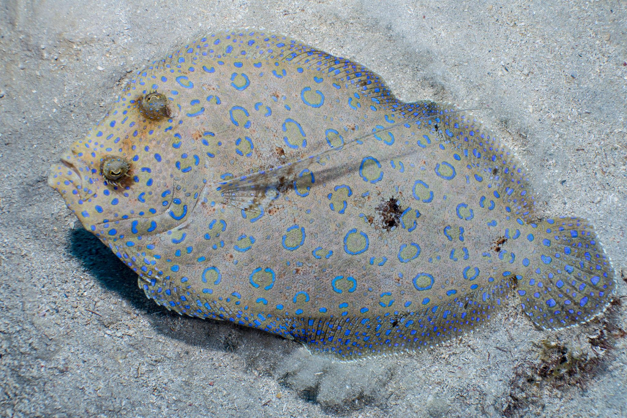

**Demersal no arrecifal**

*Bothus mancus*

Especies asociadas principalmente a fondos no arrecifales.

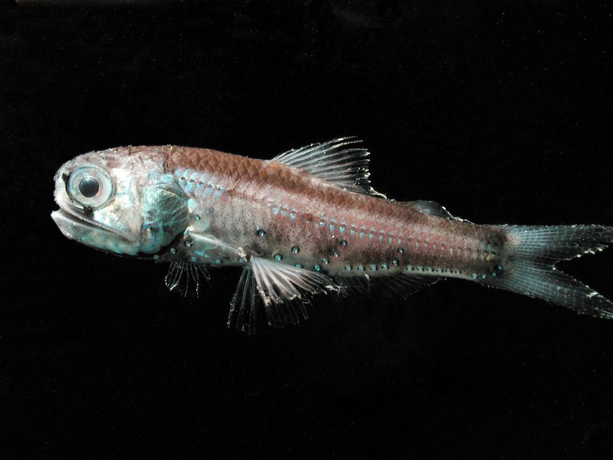

**Aguas profundas**

*Diaphus theta*

Especies asociadas a ambientes mesopelágicos y otros ambientes profundos.

**Sin clasificar**

Especies cuya afinidad ecológica requiere mayor verificación.

**Mostrar código R**

```r
species_inventory <- teleostei |>
  dplyr::group_by(species_accepted, family, genus) |>
  dplyr::summarise(
    records = dplyr::n(),
    years = dplyr::n_distinct(year_analysis),
    first_year = min(year_analysis),
    last_year = max(year_analysis),
    .groups = "drop"
  ) |>
  dplyr::arrange(dplyr::desc(records))

habitat_file <- file.path(
  paths$cin,
  "teleostei_habitat_classification.csv"
)

if (!file.exists(habitat_file)) {

  habitat_template <- species_inventory |>
    dplyr::distinct(species_accepted) |>
    dplyr::mutate(
      ecological_group = NA_character_,
      reef_associated = NA,
      reference = NA_character_,
      classification_status = "PENDIENTE"
    )

  obis_write_csv(habitat_template, habitat_file)
}

print(species_inventory, n = 20)
```

```
# A tibble: 403 × 7
   species_accepted            family   genus records years first_year last_year
   <chr>                       <chr>    <chr>   <int> <int>      <int>     <int>
 1 Bodianus diplotaenia        Labridae Bodi…    2777    32       1994      2025
 2 Mycteroperca olfax          Epineph… Myct…    2558    31       1994      2025
 3 Stegastes beebei            Pomacen… Steg…    2403    32       1994      2025
 4 Holacanthus passer          Pomacan… Hola…    2331    32       1994      2025
 5 Epinephelus labriformis     Epineph… Epin…    1961    32       1994      2025
 6 Halichoeres dispilus        Labridae Hali…    1943    31       1994      2025
 7 Scarus ghobban              Scaridae Scar…    1940    32       1994      2025
 8 Thalassoma lucasanum        Labridae Thal…    1920    32       1994      2025
 9 Ophioblennius steindachneri Blennii… Ophi…    1850    32       1994      2025
10 Johnrandallia nigrirostris  Chaetod… John…    1437    32       1994      2025
11 Plagiotremus azaleus        Blennii… Plag…    1338    31       1994      2025
12 Apogon atradorsatus         Apogoni… Apog…    1311    32       1994      2025
13 Halichoeres nicholsi        Labridae Hali…    1238    32       1994      2025
14 Stegastes arcifrons         Pomacen… Steg…    1193    31       1995      2025
15 Sufflamen verres            Balisti… Suff…    1183    32       1994      2025
16 Serranus psittacinus        Serrani… Serr…    1045    31       1994      2025
17 Cirrhitichthys oxycephalus  Cirrhit… Cirr…    1033    32       1994      2025
18 Cirrhitus rivulatus         Cirrhit… Cirr…     962    31       1995      2025
19 Acanthocybium solandri      Scombri… Acan…     947    16       1998      2025
20 Abudefduf troschelii        Pomacen… Abud…     942    32       1994      2025
# ℹ 383 more rows
```

### 10.2. Composición por grupo ecológico

Se clasifican las especies de Teleostei según su afinidad ecológica, con el propósito de comparar la representatividad de los diferentes ensamblajes presentes en la base de OBIS.

**Mostrar código R**

```
# A tibble: 7 × 4
  ecological_group              records species years
  <chr>                           <int>   <int> <int>
1 Arrecifal                       51360     128    32
2 Asociacion arrecifal variable    7421      93    32
3 Pelagico                         2098      43    29
4 Costero generalista              1653      15    31
5 Demersal no arrecifal            1635      37    32
6 Aguas profundas                   244      74    12
7 Sin clasificar                     22      13     9
```

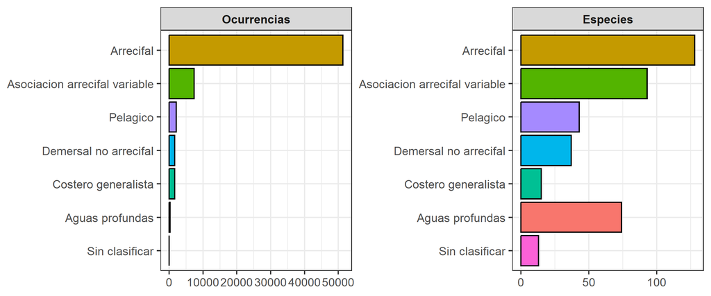

Figura 8: Número de especies y registros de ocurrencia de Teleostei según su clasificación ecológica preliminar en Galápagos durante 1994–2025.

```r
habitat <- readr::read_csv(
  file.path(paths$cin, "teleostei_habitat_classification.csv"),
  show_col_types = FALSE
)

stopifnot(!anyDuplicated(habitat$species_accepted))

teleostei_ecological <- teleostei |>
  dplyr::left_join(habitat, by = "species_accepted") |>
  dplyr::mutate(
    ecological_group = dplyr::coalesce(
      ecological_group, "Sin clasificar"
    )
  )

eco_summary <- teleostei_ecological |>
  dplyr::group_by(ecological_group) |>
  dplyr::summarise(
    records = dplyr::n(),
    species = dplyr::n_distinct(species_accepted),
    years = dplyr::n_distinct(year_analysis),
    .groups = "drop"
  ) |>
  dplyr::arrange(dplyr::desc(records))

obis_write_csv(
  eco_summary,
  file.path(paths$tab, "11_teleostei_ecological_summary.csv")
)

eco_plot <- eco_summary |>
  tidyr::pivot_longer(
    cols = c(records, species),
    names_to = "metric",
    values_to = "value"
  ) |>
  dplyr::mutate(
    metric = factor(
      metric,
      levels = c("records", "species"),
      labels = c("Ocurrencias", "Especies")
    )
  )

g_eco <- ggplot2::ggplot(
  eco_plot,
  ggplot2::aes(
    x = reorder(ecological_group, value),
    y = value,
    fill = ecological_group
  )
) +
  ggplot2::geom_col(show.legend = FALSE, col = 1) +
  ggplot2::facet_wrap(~metric, scales = "free", ncol = 2) +
  ggplot2::coord_flip() +
  ggplot2::labs(x = NULL, y = NULL) +
  ggplot2::theme_bw(base_size = 18) +
  ggplot2::theme(
    strip.text = ggplot2::element_text(face = "bold")
  )

print(g_eco)

ggplot2::ggsave(
  file.path(paths$fig, "11_teleostei_ecological_composition.png"),
  g_eco,
  width = 10, height = 5,
  dpi = 350, bg = "white"
)

print(eco_summary)
```

**Interpretación.** Los peces arrecifales concentran la mayor proporción de ocurrencias y riqueza registrada de Teleostei, seguidos por las especies con asociación arrecifal variable. Este predominio documental, junto con los antecedentes de monitoreo de comunidades arrecifales en Galápagos, sustenta preliminarmente su selección como ensamblaje focal del estudio.

### 10.3. Variación anual de ocurrencias por grupo ecológico

La Figura 9 muestra la distribución temporal de las ocurrencias de Teleostei según su afinidad ecológica. Se evalúa la continuidad de los registros y su variabilidad interanual como criterios para seleccionar el ensamblaje focal del estudio.

**Mostrar código R**

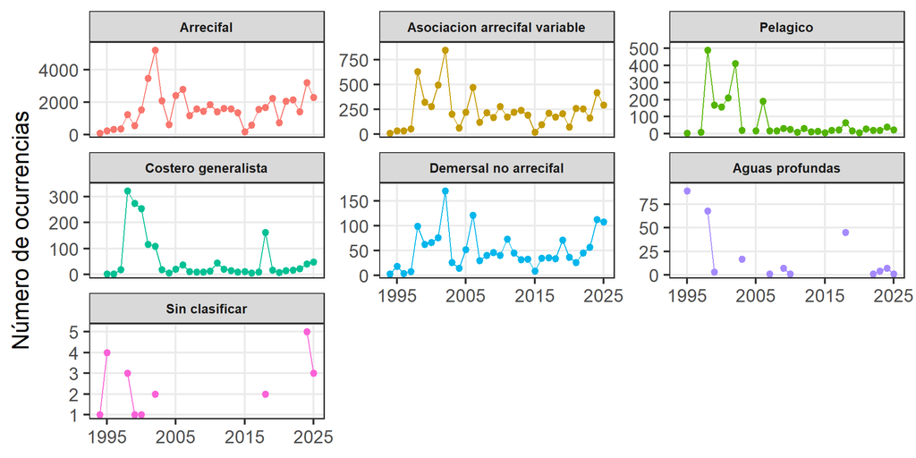

Figura 9: Variación anual del número de ocurrencias de Teleostei por grupo ecológico en el archipiélago de Galápagos durante 1994–2025. Las escalas verticales son independientes entre paneles. Fuente: OBIS, datos depurados y clasificación ecológica preliminar.

```r
# Orden de los grupos por número total de registros
eco_levels <- eco_summary |>
  dplyr::arrange(dplyr::desc(records)) |>
  dplyr::pull(ecological_group)

# Resumen anual
eco_annual <- teleostei_ecological |>
  dplyr::group_by(ecological_group, year_analysis) |>
  dplyr::summarise(
    records = dplyr::n(),
    species = dplyr::n_distinct(species_accepted),
    .groups = "drop"
  ) |>
  tidyr::complete(
    ecological_group = eco_levels,
    year_analysis = years,
    fill = list(
      records = NA_integer_,
      species = NA_integer_
    )
  ) |>
  dplyr::mutate(
    ecological_group = factor(
      ecological_group,
      levels = eco_levels
    )
  ) |>
  dplyr::arrange(ecological_group, year_analysis)

# Exportación
obis_write_csv(
  eco_annual,
  file.path(paths$tab, "11_teleostei_ecological_annual.csv")
)

# Visualización
g_eco_annual <- ggplot2::ggplot(
  eco_annual,
  ggplot2::aes(
    x = year_analysis,
    y = records,
    colour = ecological_group,
    group = ecological_group
  )
) +
  ggplot2::geom_line(linewidth = 0.4, na.rm = TRUE) +
  ggplot2::geom_point(size = 1.8, na.rm = TRUE) +
  ggplot2::facet_wrap(
    ~ ecological_group,
    scales = "free_y",
    ncol = 3
  ) +
  ggplot2::scale_x_continuous(
    breaks = seq(1995, 2025, by = 10),
    limits = range(years)
  ) +
  ggplot2::scale_y_continuous(
    expand = ggplot2::expansion(mult = c(0.05, 0.10))
  ) +
  ggplot2::labs(
    x = NULL,
    y = "Número de ocurrencias"
  ) +
  ggplot2::theme_bw(base_size = 18) +
  ggplot2::theme(
    legend.position = "none",
    strip.text = ggplot2::element_text(
      face = "bold",
      size = 10
    ),
    panel.grid.minor = ggplot2::element_blank(),
    panel.spacing = grid::unit(0.8, "lines")
  )

print(g_eco_annual)

ggplot2::ggsave(
  file.path(paths$fig, "11_teleostei_ecological_annual.png"),
  plot = g_eco_annual,
  width = 10,
  height = 6,
  dpi = 350,
  bg = "white"
)
```

**Interpretación.** Los peces arrecifales presentan la mayor cantidad de ocurrencias y una elevada continuidad temporal durante 1994–2025. En contraste, los grupos pelágicos, costeros generalistas y de aguas profundas muestran menor intensidad documental o mayor discontinuidad temporal. Estos resultados favorecen preliminarmente la selección del ensamblaje arrecifal para investigaciones de largo plazo, condicionada a la evaluación de la comparabilidad del muestreo.

### 10.4. Variación anual de la riqueza observada por grupo ecológico

La Figura 10 muestra la variación interanual del número de especies registradas por grupo ecológico, permitiendo evaluar la continuidad y representatividad taxonómica de los ensamblajes.

**Mostrar código R**

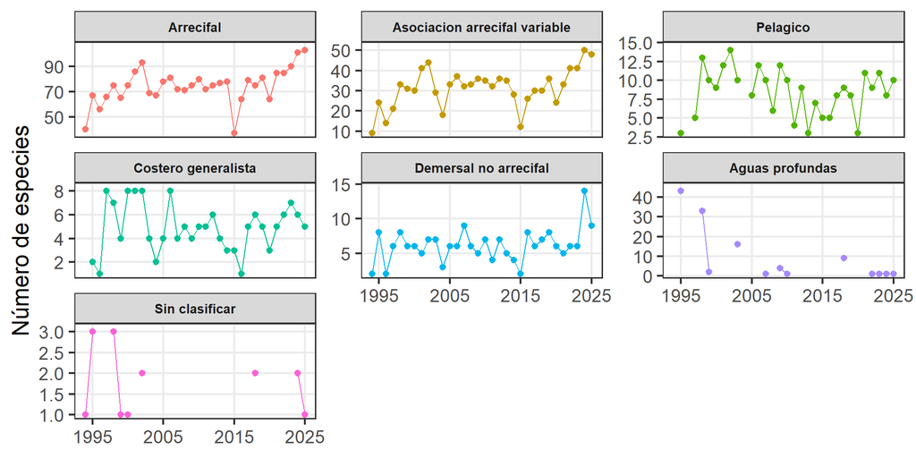

Figura 10: Variación anual de la riqueza observada de Teleostei por grupo ecológico en el archipiélago de Galápagos durante 1994–2025. Las escalas verticales son independientes entre paneles. Fuente: OBIS, datos depurados y clasificación ecológica preliminar.

```r
g_eco_richness <- ggplot2::ggplot(
  eco_annual,
  ggplot2::aes(
    x = year_analysis,
    y = species,
    colour = ecological_group,
    group = ecological_group
  )
) +
  ggplot2::geom_line(
    linewidth = 0.4,
    na.rm = TRUE
  ) +
  ggplot2::geom_point(
    size = 1.5,
    na.rm = TRUE
  ) +
  ggplot2::facet_wrap(
    ~ ecological_group,
    scales = "free_y",
    ncol = 3
  ) +
  ggplot2::scale_x_continuous(
    breaks = seq(1995, 2025, by = 10),
    limits = range(years)
  ) +
  ggplot2::scale_y_continuous(
    expand = ggplot2::expansion(
      mult = c(0.05, 0.10)
    )
  ) +
  ggplot2::labs(
    x = NULL,
    y = "Número de especies"
  ) +
  ggplot2::theme_bw(base_size = 18) +
  ggplot2::theme(
    legend.position = "none",
    strip.text = ggplot2::element_text(
      face = "bold",
      size = 10
    ),
    panel.grid.minor = ggplot2::element_blank(),
    panel.spacing = grid::unit(0.8, "lines")
  )

print(g_eco_richness)

ggplot2::ggsave(
  file.path(
    paths$fig,
    "11_teleostei_ecological_richness.png"
  ),
  plot = g_eco_richness,
  width = 10,
  height = 6,
  dpi = 350,
  bg = "white"
)
```

**Interpretación.** Los peces arrecifales presentan la mayor riqueza observada durante el periodo 1994–2025, registrándose generalmente entre 60 y 90 especies por año y superando las 100 especies en los años recientes. Las especies con asociación arrecifal variable constituyen el segundo grupo con mayor riqueza y continuidad temporal. En contraste, los grupos pelágicos, demersales y de aguas profundas presentan una menor riqueza anual documentada o mayor discontinuidad. Estos resultados respaldan preliminarmente la selección del ensamblaje arrecifal para posteriores análisis de diversidad y variabilidad ambiental.

### 10.5. Representatividad y continuidad temporal por grupo ecológico

Se integran indicadores de riqueza registrada, intensidad de ocurrencias y continuidad temporal para evaluar la idoneidad de los diferentes grupos ecológicos de Teleostei a largo plazo.

**Mostrar código R**

```r
eco_suitability <- eco_annual |>
  dplyr::group_by(ecological_group) |>
  dplyr::summarise(
    years_present = sum(records > 0, na.rm = TRUE),

    temporal_coverage = 100 * years_present / length(years),

    longest_run = {
      r <- rle(!is.na(records) & records > 0)
      max(c(0, r$lengths[r$values]))
    },

    records_mean = mean(records, na.rm = TRUE),

    records_cv = 100 * sd(records, na.rm = TRUE) /
      mean(records, na.rm = TRUE),

    richness_mean = mean(species, na.rm = TRUE),

    richness_min = min(species, na.rm = TRUE),

    richness_max = max(species, na.rm = TRUE),

    richness_cv = 100 * sd(species, na.rm = TRUE) /
      mean(species, na.rm = TRUE),

    .groups = "drop"
  ) |>
  dplyr::left_join(
    eco_summary |>
      dplyr::select(ecological_group, records, species),
    by = "ecological_group"
  ) |>
  dplyr::mutate(
    records_share = 100 * records / sum(records),
    species_share = 100 * species / sum(species)
  ) |>
  dplyr::select(
    ecological_group,
    records,
    records_share,
    species,
    species_share,
    years_present,
    temporal_coverage,
    longest_run,
    records_mean,
    records_cv,
    richness_mean,
    richness_min,
    richness_max,
    richness_cv
  ) |>
  dplyr::arrange(dplyr::desc(records))

obis_write_csv(
  eco_suitability,
  file.path(
    paths$tab,
    "11_teleostei_ecological_suitability.csv"
  )
)

knitr::kable(
  eco_suitability,
  digits = 1
)
```

Tabla 1: Indicadores de representatividad y continuidad temporal de los grupos ecológicos de Teleostei en Galápagos durante 1994–2025.

| ecological_group | records | records_share | species | species_share | years_present | temporal_coverage | longest_run | records_mean | records_cv | richness_mean | richness_min | richness_max | richness_cv |
| --- | --- | --- | --- | --- | --- | --- | --- | --- | --- | --- | --- | --- | --- |
| Arrecifal | 51360 | 79.7 | 128 | 31.8 | 32 | 100.0 | 32 | 1605.0 | 67.6 | 74.4 | 37 | 103 | 18.9 |
| Asociacion arrecifal variable | 7421 | 11.5 | 93 | 23.1 | 32 | 100.0 | 32 | 231.9 | 78.2 | 31.3 | 9 | 50 | 30.5 |
| Pelagico | 2098 | 3.3 | 43 | 10.7 | 29 | 90.6 | 21 | 72.3 | 165.9 | 8.4 | 3 | 14 | 36.8 |
| Costero generalista | 1653 | 2.6 | 15 | 3.7 | 31 | 96.9 | 31 | 53.3 | 160.0 | 4.9 | 1 | 8 | 41.6 |
| Demersal no arrecifal | 1635 | 2.5 | 37 | 9.2 | 32 | 100.0 | 32 | 51.1 | 74.1 | 6.1 | 2 | 14 | 38.4 |
| Aguas profundas | 244 | 0.4 | 74 | 18.4 | 12 | 37.5 | 4 | 20.3 | 148.5 | 9.4 | 1 | 43 | 151.4 |
| Sin clasificar | 22 | 0.0 | 13 | 3.2 | 9 | 28.1 | 3 | 2.4 | 58.3 | 1.8 | 1 | 3 | 46.9 |

**Interpretación.** Los peces arrecifales presentan la mayor representatividad (79,7 % de las ocurrencias), una riqueza acumulada de 128 especies y cobertura temporal continua durante los 32 años evaluados. Asimismo, presentan la menor variabilidad interanual relativa de la riqueza observada (CV = 18,9 %). Estos atributos, junto con los antecedentes de investigación sobre comunidades arrecifales en Galápagos, respaldan su selección como ensamblaje focal para el estudio de la diversidad y su relación con la variabilidad oceanográfica.

## 11. Caracterización espacial de Teleostei

Se examina la distribución espacial de las ocurrencias, riqueza observada y continuidad temporal de los grupos ecológicos de Teleostei mediante una cuadrícula de mayor resolución (0,05°). El objetivo es identificar patrones de concentración de ocurrencias y evaluar la cobertura geográfica de los ensamblajes presentes en el archipiélago de Galápagos.

### 11.1. Configuración espacial

**Mostrar código R**

```r
p$grid_res_map <- 0.05
grid_res_map <- as.numeric(p$grid_res_map)

stopifnot(
  length(grid_res_map) == 1L,
  is.finite(grid_res_map),
  grid_res_map > 0
)

# Dominio geográfico
bbox <- sf::st_bbox(
  c(
    xmin = p$lon_min,
    ymin = p$lat_min,
    xmax = p$lon_max,
    ymax = p$lat_max
  ),
  crs = sf::st_crs(4326)
)

# Cartografía costera de Natural Earth
coast_file <- file.path(
  paths$cin, "galapagos_coast_10m.rds"
)

if (!file.exists(coast_file)) {

  land <- rnaturalearth::ne_download(
    scale = 10,
    type = "land",
    category = "physical",
    returnclass = "sf"
  )

  land <- sf::st_transform(land, 4326)

  galapagos_land <- sf::st_crop(
    land, bbox
  )

  saveRDS(galapagos_land, coast_file)

} else {

  galapagos_land <- readRDS(coast_file)

}

# Identificación de campos geográficos
lon_col <- intersect(
  c("decimalLongitude", "longitude", "lon"),
  names(teleostei_ecological)
)

lat_col <- intersect(
  c("decimalLatitude", "latitude", "lat"),
  names(teleostei_ecological)
)

stopifnot(
  length(lon_col) > 0,
  length(lat_col) > 0
)

# Asignación de ocurrencias a celdas
teleostei_grid <- teleostei_ecological |>
  dplyr::mutate(
    lon = as.numeric(.data[[lon_col[1]]]),
    lat = as.numeric(.data[[lat_col[1]]])
  ) |>
  dplyr::filter(
    is.finite(lon),
    is.finite(lat),
    lon >= p$lon_min,
    lon <= p$lon_max,
    lat >= p$lat_min,
    lat <= p$lat_max
  ) |>
  dplyr::mutate(
    cell_x = pmin(
      floor((lon - p$lon_min) / grid_res_map),
      ceiling((p$lon_max - p$lon_min) /
                grid_res_map) - 1
    ),
    cell_y = pmin(
      floor((lat - p$lat_min) / grid_res_map),
      ceiling((p$lat_max - p$lat_min) /
                grid_res_map) - 1
    ),
    lon_grid = p$lon_min +
      (cell_x + 0.5) * grid_res_map,
    lat_grid = p$lat_min +
      (cell_y + 0.5) * grid_res_map,
    cell_id = paste(cell_x, cell_y, sep = "_")
  )

# Resumen de todas las ocurrencias
grid_total <- teleostei_grid |>
  dplyr::group_by(
    cell_id, lon_grid, lat_grid
  ) |>
  dplyr::summarise(
    records = dplyr::n(),
    species = dplyr::n_distinct(species_accepted),
    years_present = dplyr::n_distinct(year_analysis),
    .groups = "drop"
  )

# Resumen por grupo ecológico
grid_ecological <- teleostei_grid |>
  dplyr::group_by(
    ecological_group,
    cell_id, lon_grid, lat_grid
  ) |>
  dplyr::summarise(
    records = dplyr::n(),
    species = dplyr::n_distinct(species_accepted),
    years_present = dplyr::n_distinct(year_analysis),
    .groups = "drop"
  ) |>
  dplyr::mutate(
    ecological_group = factor(
      ecological_group,
      levels = eco_levels
    )
  )

# Exportación de resultados espaciales
obis_write_csv(
  grid_total,
  file.path(paths$tab, "12_teleostei_grid_total.csv")
)

obis_write_csv(
  grid_ecological,
  file.path(paths$tab, "12_teleostei_grid_ecological.csv")
)

cat(
  "\n",
  "============================================\n",
  " TELEOSTEI | CONFIGURACIÓN ESPACIAL\n",
  "============================================\n",
  " Resolución     : ", grid_res_map, "°\n",
  " Registros      : ", nrow(teleostei_grid), "\n",
  " Celdas con datos: ", nrow(grid_total), "\n",
  " Especies       : ",
  dplyr::n_distinct(teleostei_grid$species_accepted),
  "\n",
  "============================================\n",
  sep = ""
)
```

```
============================================
 TELEOSTEI | CONFIGURACIÓN ESPACIAL
============================================
 Resolución     : 0.05°
 Registros      : 64433
 Celdas con datos: 578
 Especies       : 403
============================================
```

### 11.2. Distribución espacial general de Teleostei

La Figura 11 presenta la distribución geográfica acumulada de las ocurrencias, riqueza observada y años documentados de Teleostei durante el periodo de estudio.

**Mostrar código R**

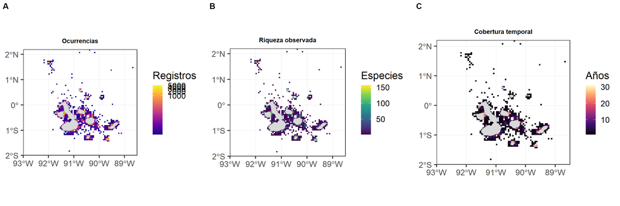

Figura 11: Distribución espacial de Teleostei en Galápagos durante 1994–2025: (A) número acumulado de ocurrencias, (B) riqueza observada y (C) número de años con registros. Resolución espacial de 0,05°. Fuente: OBIS.

```r
g_records <- plot_teleostei_map(
  data = grid_total,
  metric = "records",
  legend_title = "Registros",
  palette = "plasma",
  transform = "log1p",
  title = "Ocurrencias"
)

g_species <- plot_teleostei_map(
  data = grid_total,
  metric = "species",
  legend_title = "Especies",
  palette = "viridis",
  title = "Riqueza observada"
)

g_years <- plot_teleostei_map(
  data = grid_total,
  metric = "years_present",
  legend_title = "Años",
  palette = "magma",
  title = "Cobertura temporal"
)

g_spatial_total <- cowplot::plot_grid(
  g_records,
  g_species,
  g_years,
  ncol = 3,
  labels = c("A", "B", "C"),
  label_size = 14
)

print(g_spatial_total)

ggplot2::ggsave(
  file.path(paths$fig, "12_teleostei_spatial_total.png"),
  plot = g_spatial_total,
  width = 15,
  height = 5,
  dpi = 350,
  bg = "white"
)
```

### 11.3. Distribución espacial de ocurrencias por grupo ecológico

La Figura 12 permite comparar la distribución geográfica y concentración documental de los diferentes grupos ecológicos de Teleostei.

**Mostrar código R**

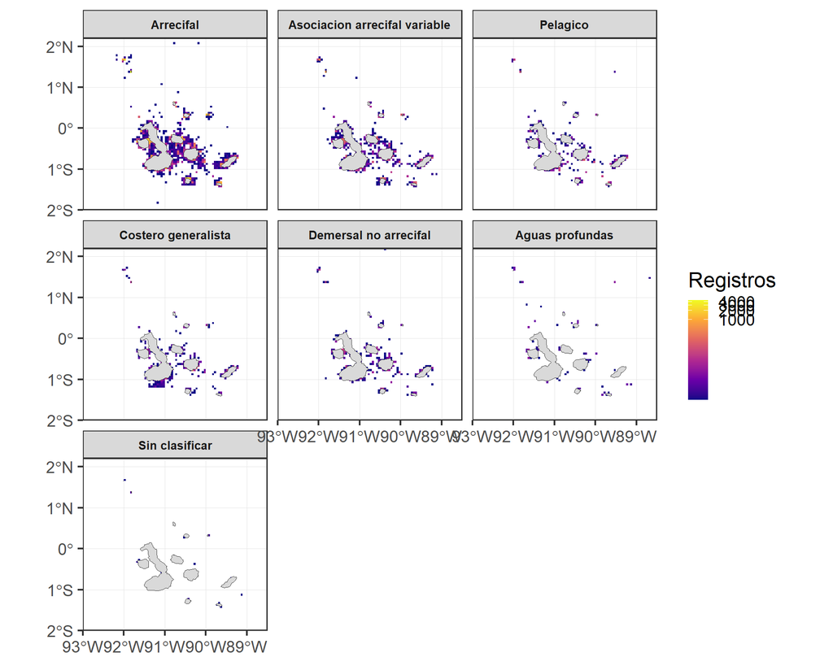

Figura 12: Distribución espacial del número acumulado de ocurrencias de Teleostei por grupo ecológico en Galápagos durante 1994–2025. Resolución espacial de 0,05°. Fuente: OBIS y clasificación ecológica preliminar.

```r
g_eco_spatial_records <- plot_teleostei_map(
  data = grid_ecological,
  metric = "records",
  legend_title = "Registros",
  palette = "plasma",
  transform = "log1p",
  facet = TRUE
)

print(g_eco_spatial_records)

ggplot2::ggsave(
  file.path(
    paths$fig,
    "12_teleostei_ecological_spatial_records.png"
  ),
  plot = g_eco_spatial_records,
  width = 12,
  height = 10,
  dpi = 350,
  bg = "white"
)
```

### 11.4. Distribución espacial de la riqueza observada

La Figura 13 muestra la distribución espacial del número acumulado de especies registradas por grupo ecológico.

**Mostrar código R**

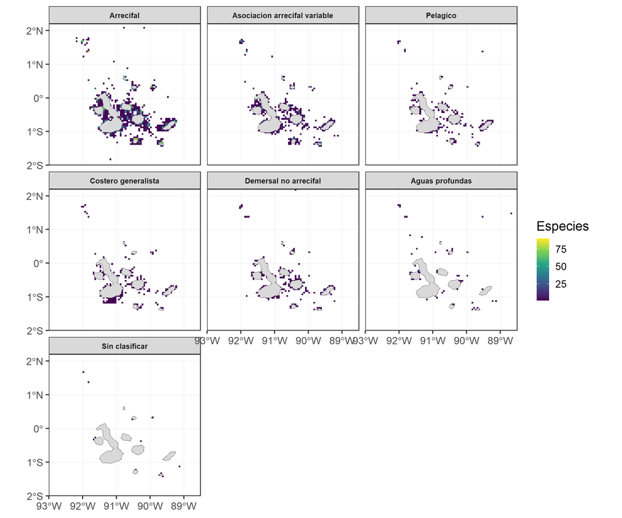

Figura 13: Distribución espacial de la riqueza observada de Teleostei por grupo ecológico en Galápagos durante 1994–2025. Resolución espacial de 0,05°. Fuente: OBIS y clasificación ecológica preliminar.

```r
g_eco_spatial_species <- plot_teleostei_map(
  data = grid_ecological,
  metric = "species",
  legend_title = "Especies",
  palette = "viridis",
  facet = TRUE
)

print(g_eco_spatial_species)

ggplot2::ggsave(
  file.path(
    paths$fig,
    "12_teleostei_ecological_spatial_species.png"
  ),
  plot = g_eco_spatial_species,
  width = 12,
  height = 10,
  dpi = 350,
  bg = "white"
)
```

### 11.5. Cobertura temporal por celda geográfica

La Figura 14 presenta el número de años con ocurrencias documentadas por celda y grupo ecológico, permitiendo identificar áreas con documentación recurrente y evaluar su potencial para estudios de largo plazo.

**Mostrar código R**

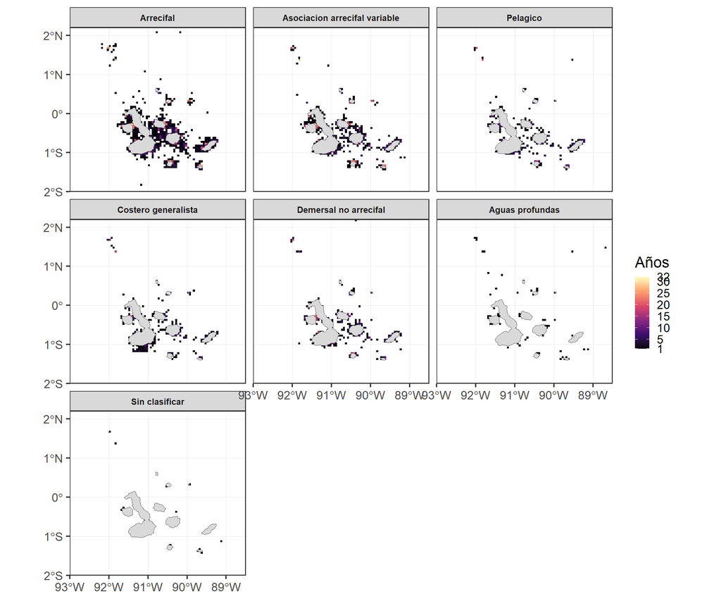

Figura 14: Distribución espacial del número de años con ocurrencias documentadas de Teleostei por grupo ecológico en Galápagos durante 1994–2025. Resolución espacial de 0,05°. Fuente: OBIS.

```r
g_eco_spatial_years <- plot_teleostei_map(
  data = grid_ecological,
  metric = "years_present",
  legend_title = "Años",
  palette = "magma",
  facet = TRUE
) +
  ggplot2::scale_fill_viridis_c(
    option = "magma",
    limits = c(1, length(years)),
    breaks = c(1, 5, 10, 15, 20, 25, 30, 32),
    name = "Años"
  )

print(g_eco_spatial_years)

ggplot2::ggsave(
  file.path(
    paths$fig,
    "12_teleostei_ecological_spatial_years.png"
  ),
  plot = g_eco_spatial_years,
  width = 12,
  height = 10,
  dpi = 350,
  bg = "white"
)
```

## 12. Selección del ensamblaje de peces arrecifales

Los peces arrecifales y las especies con asociación arrecifal variable fueron seleccionados por su elevada representatividad taxonómica, espacial y temporal. En conjunto, concentran 58 781 ocurrencias correspondientes a 221 especies, representando el 91,2 % de los registros de Teleostei y cubriendo la totalidad del periodo 1994–2025.

Esta selección es coherente con los antecedentes de investigación sobre comunidades arrecifales, diversidad funcional y biogeografía marina del archipiélago de Galápagos (Edgar et al., 2004; McKinley et al., 2022, 2023).

**Mostrar código R**

```r
reef_groups <- c(
  "Arrecifal",
  "Asociacion arrecifal variable"
)

reef_fishes <- teleostei_ecological |>
  dplyr::filter(
    ecological_group %in% reef_groups
  ) |>
  dplyr::mutate(
    ecological_group = factor(
      ecological_group,
      levels = reef_groups
    )
  ) |>
  dplyr::arrange(
    year_analysis,
    month_analysis,
    species_accepted
  )

stopifnot(nrow(reef_fishes) > 0)

reef_summary <- reef_fishes |>
  dplyr::group_by(ecological_group) |>
  dplyr::summarise(
    records = dplyr::n(),
    species = dplyr::n_distinct(species_accepted),
    families = dplyr::n_distinct(family, na.rm = TRUE),
    years = dplyr::n_distinct(year_analysis),
    first_year = min(year_analysis),
    last_year = max(year_analysis),
    .groups = "drop"
  )

file_reef <- file.path(
  paths$cin,
  sprintf(
    "obis_reef_fishes_%d_%d.csv",
    min(years),
    max(years)
  )
)

obis_write_csv(reef_fishes, file_reef)

obis_write_csv(
  reef_summary,
  file.path(paths$tab, "13_reef_fishes_summary.csv")
)

print(reef_summary)
```

```
# A tibble: 2 × 7
  ecological_group           records species families years first_year last_year
  <fct>                        <int>   <int>    <int> <int>      <int>     <int>
1 Arrecifal                    51360     128       32    32       1994      2025
2 Asociacion arrecifal vari…    7421      93       35    32       1994      2025
```

**Mostrar código R**

```r
cat(
  "\n",
  "============================================\n",
  " OBIS | ENSAMBLAJE FOCAL SELECCIONADO\n",
  "============================================\n",
  " Ocurrencias : ", nrow(reef_fishes), "\n",
  " Especies    : ",
  dplyr::n_distinct(reef_fishes$species_accepted), "\n",
  " Familias    : ",
  dplyr::n_distinct(reef_fishes$family, na.rm = TRUE), "\n",
  " Años        : ",
  dplyr::n_distinct(reef_fishes$year_analysis), "\n",
  " Archivo     : ", file_reef, "\n",
  "============================================\n",
  sep = ""
)
```

```
============================================
 OBIS | ENSAMBLAJE FOCAL SELECCIONADO
============================================
 Ocurrencias : 58781
 Especies    : 221
 Familias    : 51
 Años        : 32
 Archivo     : D:/ios/OceanHackWeek2026/ohwe26-proy1-GBIF_analisis_espacial/projectOBIS/cin/obis_reef_fishes_1994_2025.csv
============================================
```

## 13. Estructura y continuidad del proyecto

El proyecto se organiza en cinco etapas, desde la adquisición y selección de registros de biodiversidad marina hasta la evaluación de las relaciones entre la diversidad de peces arrecifales y la variabilidad oceanográfica del archipiélago de Galápagos.

Estructura del proyecto sobre la diversidad de peces arrecifales y su relación con la variabilidad oceanográfica en el archipiélago de Galápagos.

| Etapa | Documento | Objetivo | Producto principal |
| --- | --- | --- | --- |
| **01** | `01_obis_seleccion_taxonomica.qmd` | Adquisición, depuración, análisis exploratorio y selección del ensamblaje arrecifal. | Base estandarizada de ocurrencias de peces arrecifales y especies con asociación arrecifal variable. |
| **02** | `02_reef_fishes_characterization.qmd` | Caracterización taxonómica, espacial, temporal del ensamblaje | Base con unidades de muestreo comparables, estaciones, eventos y bioregiones. |
| **03** | `03_reef_fishes_diversity.qmd` | Evaluación de la completitud del muestreo, rarefacción, diversidad alfa y beta, recambio de especies y anidamiento. | Indicadores de diversidad taxonómica y cambios en la composición de los ensamblajes. |
| **04** | `04_reef_fishes_oceanography.qmd` | Caracterización de la variabilidad oceanográfica y extracción espacio-temporal de covariables ambientales. | Base integrada de variables oceanográficas asociadas a las unidades de muestreo. |
| **05** | `05_reef_fishes_environment.qmd` | Evaluación de las relaciones entre diversidad, composición comunitaria y variabilidad ambiental mediante modelos estadísticos. | Modelos ecológicos, evaluación de hipótesis y resultados para la elaboración del artículo científico. |

```
flowchart TD

    A["QMD 01 - Adquisición y selección taxonómica"]
    B["QMD 02 - Caracterización del ensamblaje arrecifal"]
    C["QMD 03 - Evaluación de la diversidad"]
    D["QMD 04 - Caracterización oceanográfica"]
    E["QMD 05 - Modelamiento ecológico-ambiental"]

    A --> B
    B --> C
    B --> D
    C --> E
    D --> E

    style A fill:#D4EFDF,stroke:#196F3D,color:#000000
    style B fill:#F2F3F4,stroke:#566573,color:#000000
    style C fill:#F2F3F4,stroke:#566573,color:#000000
    style D fill:#F2F3F4,stroke:#566573,color:#000000
    style E fill:#D6EAF8,stroke:#21618C,color:#000000
```

Figura 15: Flujo metodológico del proyecto de investigación.

### Referencias

- Bonnet-Lebrun, A.-S., Sweetlove, M., Griffiths, H. J., Sumner, M., Provoost, P., Raymond, B., Ropert-Coudert, Y., & Van de Putte, A. P. (2023). Opportunities and limitations of large open biodiversity occurrence databases in the context of a Marine Ecosystem Assessment of the Southern Ocean. *Frontiers in Marine Science, 10*, Article 1150603. https://doi.org/10.3389/fmars.2023.1150603
- Bruneel, S., Van Echelpoel, W., Ho, L., Raat, H., Schoeters, A., De Troyer, N., Sor, R., Ponton-Cevallos, J., Vandeputte, R., Van der Heyden, C., De Saeyer, N., Forio, M. A. E., Bermudez, R., Dominguez-Granda, L., Luca, S., Moens, T., & Goethals, P. (2021). Assessing the drivers behind the structure and diversity of fish assemblages associated with rocky shores in the Galapagos Archipelago. *Journal of Marine Science and Engineering, 9*(4), Article 375. https://doi.org/10.3390/jmse9040375
- Chao, A., & Jost, L. (2012). Coverage-based rarefaction and extrapolation: Standardizing samples by completeness rather than size. *Ecology, 93*(12), 2533–2547. https://doi.org/10.1890/11-1952.1
- Edgar, G. J., Banks, S., Fariña, J. M., Calvopiña, M., & Martínez, C. (2004). Regional biogeography of shallow reef fish and macro-invertebrate communities in the Galapagos archipelago. *Journal of Biogeography, 31*(7), 1107–1124. https://doi.org/10.1111/j.1365-2699.2004.01055.x
- Froese, R., & Pauly, D. (Eds.). (s. f.). *FishBase*. World Wide Web electronic publication. https://www.fishbase.org
- Fundación Charles Darwin. (2023). *Galapagos Subtidal Biodiversity* [Conjunto de datos de ocurrencias]. Global Biodiversity Information Facility (GBIF). https://doi.org/10.15468/gsa458
- Fundación Charles Darwin. (s. f.). *Galapagos Species Database*. DataZone. https://datazone.darwinfoundation.org/es/checklist/
- Hsieh, T. C., Ma, K. H., & Chao, A. (2016). iNEXT: An R package for rarefaction and extrapolation of species diversity (Hill numbers). *Methods in Ecology and Evolution, 7*(12), 1451–1456. https://doi.org/10.1111/2041-210X.12613
- McKinley, S. J., Saunders, B. J., Rastoin-Laplane, E., Salinas-de-León, P., & Harvey, E. S. (2022). Functional diversity of reef fish assemblages in the Galapagos Archipelago. *Journal of Experimental Marine Biology and Ecology, 549*, Article 151695. https://doi.org/10.1016/j.jembe.2022.151695
- McKinley, S. J., Saunders, B. J., Rastoin-Laplane, E., Salinas-de-León, P., & Harvey, E. S. (2023). Functional vulnerability and biogeography of reef fish assemblages in the Galapagos Archipelago. *Estuarine, Coastal and Shelf Science, 286*, Article 108301. https://doi.org/10.1016/j.ecss.2023.108301
- Menegotto, A., & Rangel, T. F. (2018). Mapping knowledge gaps in marine diversity reveals a latitudinal gradient of missing species richness. *Nature Communications, 9*, Article 4713. https://doi.org/10.1038/s41467-018-07217-7
- Moity, N. (2019). *Marine bioregions for coastal subtidal shallow rocky reef of the Galapagos Archipelago, GIS layer for Edgar et al. 2004* [Conjunto de datos geoespaciales]. PANGAEA. https://doi.org/10.1594/PANGAEA.907105
- Mora, C., Tittensor, D. P., & Myers, R. A. (2008). The completeness of taxonomic inventories for describing the global diversity and distribution of marine fishes. *Proceedings of the Royal Society B: Biological Sciences, 275*, 149–155. https://doi.org/10.1098/rspb.2007.1315
- Natural Earth. (s. f.). *Natural Earth: 1:10m physical vectors – Land* [Conjunto de datos cartográficos]. https://www.naturalearthdata.com
- Ocean Biodiversity Information System (OBIS). (s. f.). *Data access*. En *The OBIS manual*. https://manual.obis.org/access
- Ocean Biodiversity Information System (OBIS). (s. f.). *Data quality flags*. En *The OBIS manual*. https://manual.obis.org/dataquality.html
- Ocean Biodiversity Information System (OBIS). (s. f.). *Constructing and using identifiers*. En *The OBIS manual*. https://manual.obis.org/identifiers.html
- Ocean Biodiversity Information System (OBIS). (s. f.). *Occurrence: Get occurrence records*. En *robis reference*. https://iobis.github.io/robis/reference/occurrence.html
- Rastoin-Laplane, E., Salinas-de-León, P., Goetze, J. S., Saunders, B. J., McKinley, S. J., Norris, C., Gosby, C., Mattingly, A., Garcia, R., & Harvey, E. S. (2023). Fluctuations of Galapagos mid-water and benthic reef fish populations during the 2015–16 ENSO. *Estuarine, Coastal and Shelf Science, 294*, Article 108523. https://doi.org/10.1016/j.ecss.2023.108523
- Riofrío-Lazo, M., Zetina-Rejón, M. J., Vaca-Pita, L., Murillo-Posada, J. C., & Páez-Rosas, D. (2022). Fish diversity patterns along coastal habitats of the southeastern Galapagos archipelago and their relationship with environmental variables. *Scientific Reports, 12*, Article 3604. https://doi.org/10.1038/s41598-022-07601-w
- Saeedi, H. (2026). Gaps and drivers of global marine animal biodiversity from the surface to abyss. *Nature Communications, 17*, Article 4553. https://doi.org/10.1038/s41467-026-73613-z
- Smithsonian Tropical Research Institute (STRI). (s. f.). *Shorefishes of the Eastern Pacific: Online information system*. https://biogeodb.stri.si.edu/sftep/en/pages/generalinfo
- Vandepitte, L., Bosch, S., Tyberghein, L., Waumans, F., Vanhoorne, B., Hernandez, F., De Clerck, O., & Mees, J. (2015). Fishing for data and sorting the catch: Assessing the data quality, completeness and fitness for use of data in marine biogeographic databases. *Database, 2015*, Article bau125. https://doi.org/10.1093/database/bau125
- Victor, B. C., Grove, J. S., Long, D. J., Robertson, D. R., Keith, I., Bensted-Smith, W., & Salinas-de-Leon, P. (2026). List of fishes of the Galapagos Archipelago, Ecuador (Version 3.0). *Journal of the Ocean Science Foundation, 46*, 15–62. https://doi.org/10.5281/zenodo.20483239
- WoRMS Editorial Board. (s. f.). *World Register of Marine Species*. https://www.marinespecies.org